# Effect of Users Categories and Time on the Number of Trips

## by Mostafa Hasan Mahmoud

## Investigation Overview

In this investigation, I wanted to look at the categories and times of rides that can be used to predict the rides counts. The main focus was on the following columns: duration_sec, start_station_name, end_station_name, bike_id, user_type, member_gender, bike_share_for_all_trip, stday_name, stday_num, sthour, and member_age_2019.

## Dataset Overview

The dataset containing information about individual rides made in a bike-sharing system covering the greater San Francisco Bay area from 2019-02-01 to 2019-02-28 with a total of 28 days, containing 183412 rows and 16 columns.

## Distribution of the Rides Duration in Seconds

The duration of trips in the data set takes a very large range of values, from 61 to 84548 s, with the maximum turning out to be 7958 s after removing outliers. The ride duration distribution takes a unimodal shape, and the beak ranges between 261 and 361 seconds.

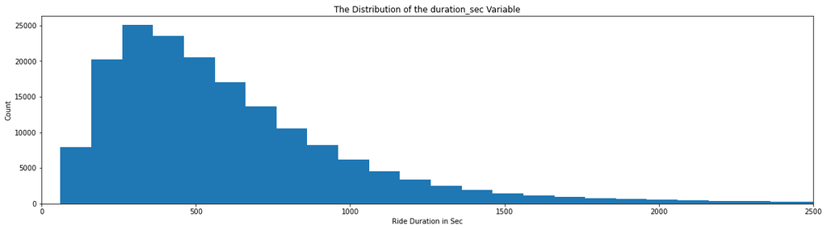

```python
binsize = 100
bins = np.arange(61, fgb['duration_sec'].max()+binsize, binsize)

plt.figure(figsize=[20, 5])
plt.hist(data = fgb, x = 'duration_sec', bins = bins)
plt.xlabel('Ride Duration in Sec')
plt.ylabel('Count')
plt.title('The Distribution of the duration_sec Variable')
plt.xlim(0, 2500)
plt.show()
```

## Distribution of the Total Number of Rides Made Each Day

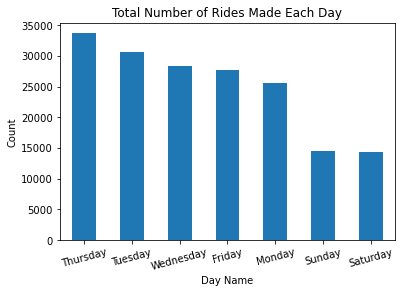

```python
rides_stday_name = fgb.stday_name.value_counts()
rides_stday_name.plot(kind='bar');
plt.xticks(rotation=15);
plt.xlabel('Day Name')
plt.ylabel('Count')
plt.title('Total Number of Rides Made Each Day');
```

## Distribution of the Total Number of Rides Made by Hour

Breaking down the total number of rides made by hour shows that the number of rides increases from 7 am to 9 pm with maximum rides at 5 pm and 8 am respectively. And minimum rides are from 0 am to 6 am.

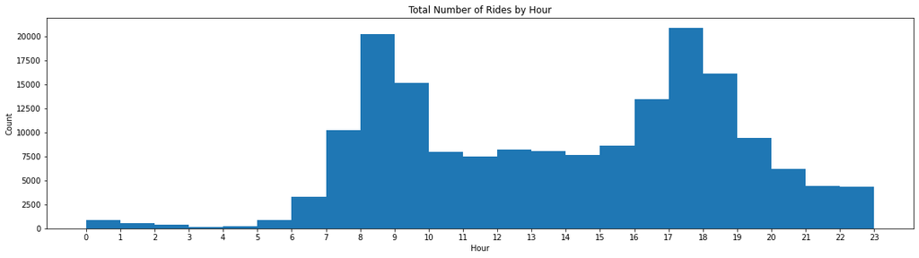

```python
plt.figure(figsize=[20, 5])
bins = np.arange(0, 24, 1)
fgb.sthour.plot(kind='hist', bins=bins)
plt.xticks(np.arange(0, 24, step=1));
plt.xlabel('Hour')
plt.ylabel('Count')
plt.title('Total Number of Rides by Hour');
```

## Distribution of the Total Number of Rides Made by Start Stations (Highest)

The highest starting stations in the total number of rides are "Market St at 10th St", "San Francisco Caltrain Station 2 (Townsend St at 4th St)", "Berry St at 4th St".

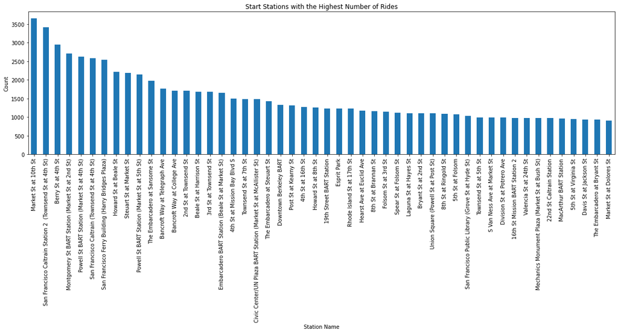

```python
plt.figure(figsize=[20, 5])
fgb['start_station_name'].value_counts().iloc[0:50].plot(kind= 'bar');
plt.xlabel('Station Name')
plt.ylabel('Count')
plt.title('Start Stations with the Highest Number of Rides');
```

## Distribution of the Total Number of Rides Made by Start Stations (Lowest)

The lowest starting stations in the total number of rides are "21st Ave at International Blvd", "Palm St at Willow St", "16th St Depot".

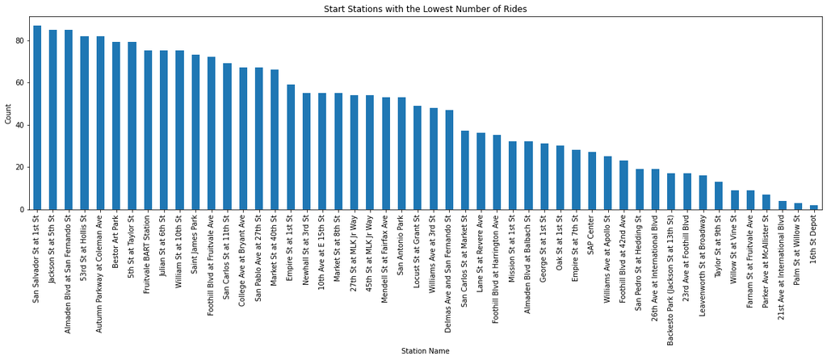

```python
plt.figure(figsize=[20, 5])
fgb['start_station_name'].value_counts().iloc[-50:].plot(kind= 'bar');
plt.xlabel('Station Name')
plt.ylabel('Count')
plt.title('Start Stations with the Lowest Number of Rides');
```

## Distribution of the Total Number of Rides Made by Bike ID

It was noted that some bikes made 179 rides and others only made one. The most used bike id is from 3991 to 6638.

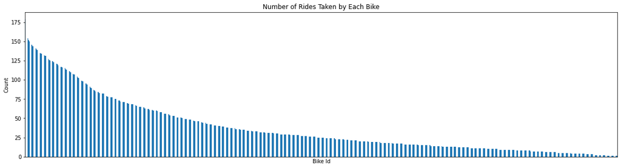

```python
plt.figure(figsize=[20, 5])
fgb.bike_id.value_counts().plot(kind = 'bar');
plt.xticks([]);
plt.xlabel('Bike Id')
plt.ylabel('Count')
plt.title('Number of Rides Taken by Each Bike');
```

## Distribution of the Total Number of Rides Made by User Type

It was noted that 90% of rides is taken by subscribers.

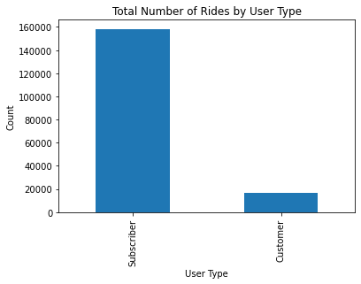

```python
fgb.user_type.value_counts().plot(kind = 'bar');
plt.xlabel('User Type')
plt.ylabel('Count')
plt.title('Total Number of Rides by User Type');
```

## Distribution of the Total Number of Rides Made by Member Age

Most of the rides were observed in the age group of users between 24 and 31 years old, often the older the member, the lower the total number of rides made.

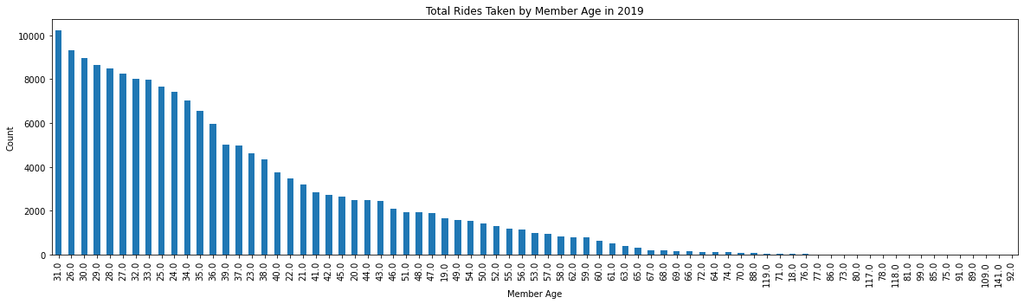

```python
plt.figure(figsize=[20, 5])
fgb.member_age_2019.value_counts().plot(kind = 'bar');
plt.xlabel('Member Age')
plt.ylabel('Count')
plt.title('Total Rides Taken by Member Age in 2019');
```

## Distribution of the Total Number of Rides Made by Gender Type

It is observed that male users represent 75% of the total users, while female users represent 23% of the total users, while other users represent only 2% of the total users.

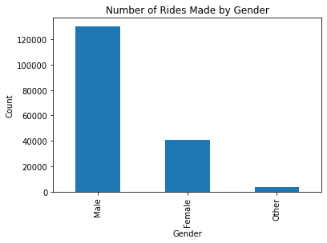

```python
fgb.member_gender.value_counts().plot(kind = 'bar');
plt.xlabel('Gender')
plt.ylabel('Count')
plt.title('Number of Rides Made by Gender');
```

## Distribution of the Total Number of Rides Made by Bike Share for All Trips

It was noted that most rides are not members of bike_share_for_all_trip.

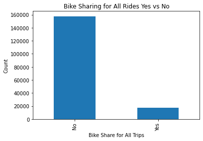

```python
fgb.bike_share_for_all_trip.value_counts().plot(kind = 'bar');
plt.xlabel('Bike Share for All Trips')
plt.ylabel('Count')
plt.title('Bike Sharing for All Rides Yes vs No');
```

## User Type vs. Duration in Seconds

It was observed that the average ride duration of the “Customer” user type was higher than that of the “Subscriber” user type and with a higher frequency.

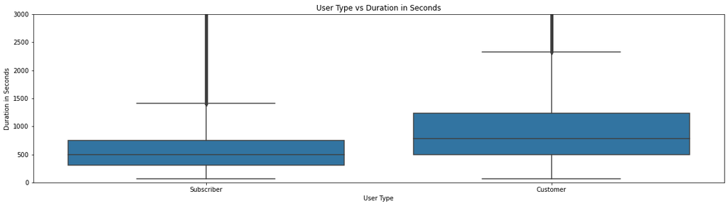

```python
plt.figure(figsize=[20, 5])
base_color = sb.color_palette()[0]
sb.boxplot(data=fgb, x='user_type', y='duration_sec', color=base_color);
#plt.xticks(rotation=90);
plt.ylim(0, 3000);
plt.xlabel('User Type')
plt.ylabel('Duration in Seconds')
plt.title('User Type vs Duration in Seconds');
```

## Bike Share for All Trips vs. Duration in Seconds

Riding duration was observed to be higher for non-bike_share_for_all_trip users. And a high median for non-bike_share_for_all_trip users.

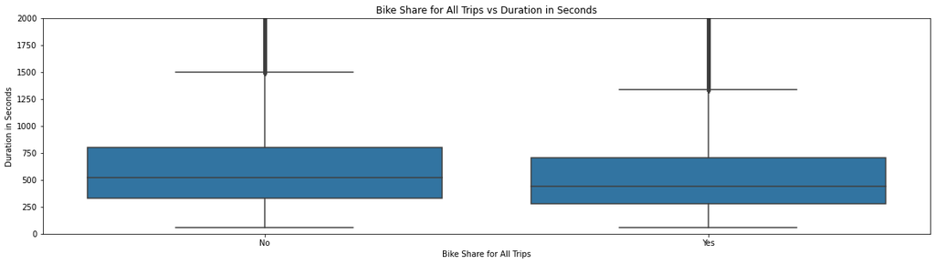

```python
plt.figure(figsize=[20, 5])
base_color = sb.color_palette()[0]
sb.boxplot(data=fgb, x='bike_share_for_all_trip', y='duration_sec', color=base_color);
plt.ylim(0, 2000);
plt.xlabel('Bike Share for All Trips')
plt.ylabel('Duration in Seconds')
plt.title('Bike Share for All Trips vs Duration in Seconds');
```

## Start Station Name vs. User Type (Sorted Descending by Subscriber Count)

It was observed that the numbers of the Subscriber user type are much larger than the numbers of the Customer type in all stations. The highest number of Subscriber users is 3369.0 on Market Street at 10th St.

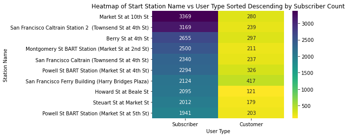

```python
sb.heatmap(counts_subscriber, annot=True, fmt='d', cmap='viridis_r');
plt.xlabel('User Type')
plt.ylabel('Station Name')
plt.title('Heatmap of Start Station Name vs User Type Sorted Descending by Subscriber Count');
```

## Start Station Name vs. User Type (Sorted Descending by Customer Count)

It was observed that the numbers of the Subscriber user type are much larger than the numbers of the Customer type in all stations. The highest number of Customer users is 417.0 at the San Francisco Ferry Building (Harry Bridges Plaza) station.

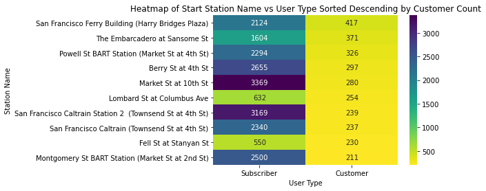

```python
sb.heatmap(counts_customer, annot=True, fmt='d', cmap='viridis_r');
plt.xlabel('User Type')
plt.ylabel('Station Name')
plt.title('Heatmap of Start Station Name vs User Type Sorted Descending by Customer Count');
```

## User Type vs. Bike Share for All Trips

It was noted that ("bike_share_for_all_trip":No) count for Subscribers is larger than Customer, and only Subscribers has ("bike_share_for_all_trip":Yes).

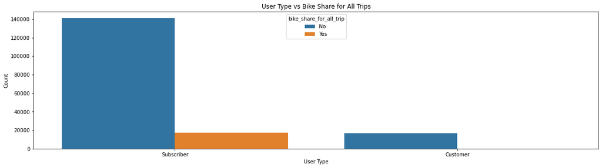

```python
plt.figure(figsize= [20, 5])
sb.countplot(data=fgb, x='user_type', hue='bike_share_for_all_trip');
plt.xlabel('User Type')
plt.ylabel('Count')
plt.title('User Type vs Bike Share for All Trips');
```

## Rides Duration in Seconds by Member Age, Start Day Name, and User Type

It was observed that Subscribers made more trips, more frequency in the duration of Subscribers’ rides, and most of the high-duration rides were made by Customers. An increase in the age groups of Subscribers from Customers.

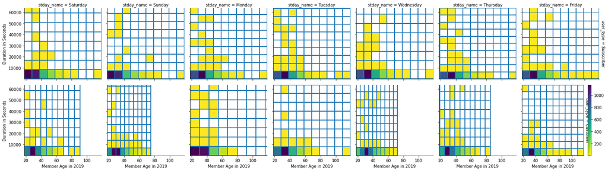

```python
g= sb.FacetGrid(data=fgb, col='stday_name', row='user_type', margin_titles=True)
g.map_dataframe(plt.hist2d, 'member_age_2019', 'duration_sec', cmin=0.5, cmap='viridis_r');
plt.colorbar();
g.set_xlabels('Member Age in 2019')
g.set_ylabels('Duration in Seconds');
```